# Exercício R

Amanda Provetti

4/13/2020

```r
library(seasonal)
```

# Parte 1

## 1. Visualização básica de dados

1. Construa um novo tibble no qual todas as variáveis sejam disponibilizadas em número índice, assumindo valor 100 no primeiro trimestre do ano 2000 (ie 2010Q1 = 100).

```r
#Carrega arquivo
load(file="./lista_stat_R/us_change.rda")

us_change.nivel = us_change

#Índice da linha correspondente ao primeiro trimestre de 2000.
line_index <- which(us_change.nivel$Quarter == "2000-01-01")[1]

for(i in 2:length(us_change.nivel)){
  if (i == line_index) {
    us_change.nivel$Consumption[i] <-  100;
    us_change.nivel$Income[i] <-  100;
    us_change.nivel$Production[i] <-  100;
    us_change.nivel$Savings[i] <-  100;
    us_change.nivel$Unemployment[i] <-  100;
  } else {
      us_change.nivel$Consumption[i] <- (1 + us_change$Consumption[i]/100) * us_change.nivel$Consumption[i-1]
      us_change.nivel$Production[i] <- (1 + us_change$Production[i]/100) * us_change.nivel$Production[i-1]
      us_change.nivel$Income[i] <- (1 + us_change$Income[i]/100) * us_change.nivel$Income[i-1]
      us_change.nivel$Savings[i] <- (1 + us_change$Savings[i]/100) * us_change.nivel$Savings[i-1]
      us_change.nivel$Unemployment[i] <-(1 + us_change$Unemployment[i]/100) * us_change.nivel$Unemployment[i-1]
  }

}
```

2. Explore a correlação entre as variáveis. Qual a diferença entre se calcular a correlação das variáveis em número índice e em taxa de variação?

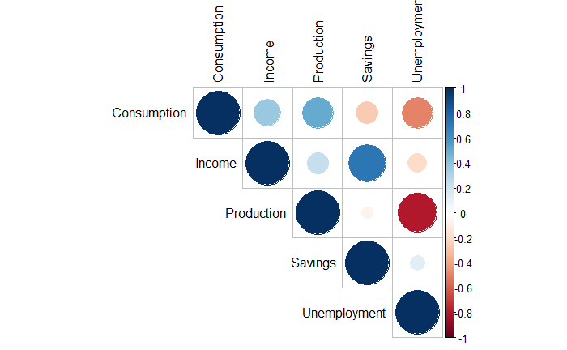

```r
correl <-  cor(us_change.nivel %>%
      select(-"Quarter")) %>% round(2)

#print(correl)
corrplot::corrplot(correl,
         type = "upper",
         tl.col = "black",
   )
```

3. Construa gráficos que contribuam em seu entendimento sobre a dinâmica de cada variável do dataset, bem como as relações entre elas. Assim, por exemplo, como ponto de partida plote gráficos de dispersão conjunta das variáveis, bem como suas evoluções ao longo do tempo. Sinta-se livre para complementar tal caracterização com todo e qualquer arsenal analítico que julgue interessante.

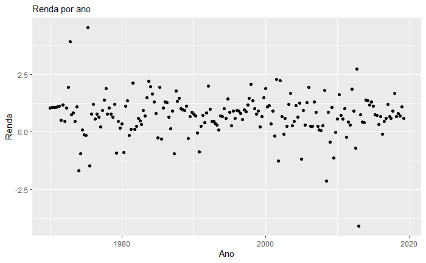

```r
graf_disp <- ggplot(us_change.nivel, aes(x=Quarter, y=Income)) +
  geom_point() +
  labs(subtitle = "Renda por ano",
       y = "Renda", x = "Ano")

plot(graf_disp)
```

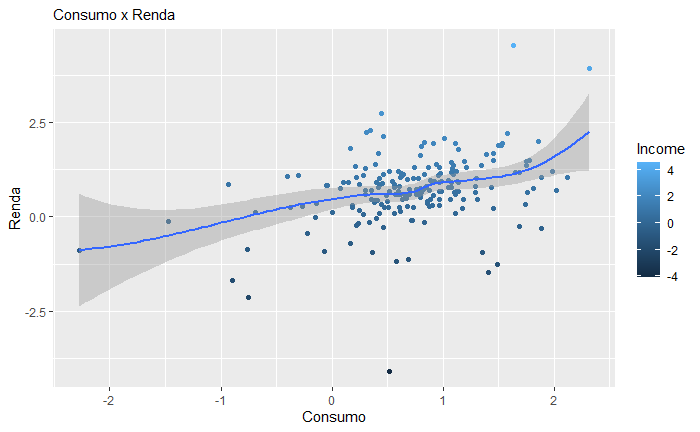

```r
graf_disp <- ggplot(us_change.nivel, aes(x=Consumption, y=Income)) +
  geom_point(aes(col=Income)) +
  geom_smooth(method="loess") +
  labs(subtitle = "Consumo x Renda",
       y = "Renda", x = "Consumo")

plot(graf_disp)
```

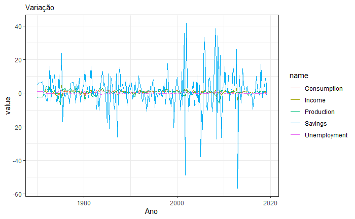

```r
us_change.plot <-  us_change.nivel %>%
  pivot_longer(
    cols =  us_change %>%
      select(-Quarter) %>%
      colnames()
  )

us_change.plot %>%
  ggplot( aes(x = Quarter, y = value, color = name)) +
  geom_line() +
  theme_bw() +
  labs(subtitle = "Variação", x = "Ano")
```

4. A partir das visualizações obtidas no item anterior, que tipo de aprendizado você consegue extrair acerca de (i) evolução das variáveis ao longo do tempo e (ii) das correlações nas dinâmicas das diversas variáveis?

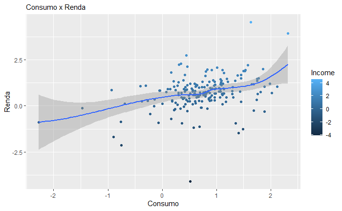

```r
# Aumento do consumo baseado no aumento da renda
graf_disp <- ggplot(us_change.nivel, aes(x=Consumption, y=Income)) +
  geom_point(aes(col=Income)) +
  geom_smooth(method="loess") +
  labs(subtitle = "Consumo x Renda",
       y = "Renda", x = "Consumo")

plot(graf_disp)
```

5. Você consegue identificar, visualmente, alguns movimentos bruscos/atípicos/anômalos na evolução das séries? Tente destacar tais pontos nos gráficos construídos

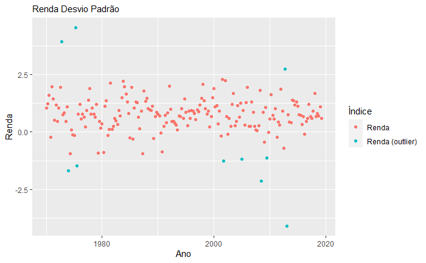

```r
outlier <- boxplot.stats(us_change$Income)$out

outlier_graph <-
  ggplot(us_change, aes(x=Quarter)) +
  geom_point(aes(y=Income, color = ifelse((Income %in% outlier),
                                           "Renda (outlier)",
                                           "Renda"))) +
  labs(subtitle = "Renda Desvio Padrão",
       y = "Renda",
       x = "Ano",
       color = "Índice")
plot(outlier_graph)
```

## 2. Séries de tempo, ciclo, sazonalidade e tendência

O arquivo “retail.xlsx” contém informações sobre vendas mensais de varejo para diversos estados da Austrália.

1. Leia os dados contidos no arquivo “retail.xlsx”. Qual cuidado adicional você precisou ter ao realizar essa importação?

Foi preciso limpar o nomes das colunas utilizando a função **clean_names()**;

```r
retail <- readxl::read_excel(path = "./lista_stat_R/retail.xlsx")
```

```
* `` -> ...1
```

```r
retail <- janitor::clean_names(retail)

print(retail)
```

| x1 | turnover_new_south_wales_supermarket_and_grocery_stores | turnover_new_south_wales_liquor_retailing | turnover_new_south_wales_other_specialised_food_retailing | turnover_new_south_wales_food_retailing | turnover_new_south_wales_furniture_floor_coverings_houseware_and_textile_goods_retailing | turnover_new_south_wales_electrical_and_electronic_goods_retailing | turnover_new_south_wales_hardware_building_and_garden_supplies_retailing | turnover_new_south_wales_household_goods_retailing | turnover_new_south_wales_clothing_retailing | turnover_new_south_wales_footwear_and_other_personal_accessory_retailing | turnover_new_south_wales_clothing_footwear_and_personal_accessory_retailing | turnover_new_south_wales_department_stores | turnover_new_south_wales_newspaper_and_book_retailing | turnover_new_south_wales_other_recreational_goods_retailing | turnover_new_south_wales_pharmaceutical_cosmetic_and_toiletry_goods_retailing | turnover_new_south_wales_other_retailing_n_e_c | turnover_new_south_wales_other_retailing | turnover_new_south_wales_cafes_restaurants_and_catering_services | turnover_new_south_wales_takeaway_food_services | turnover_new_south_wales_cafes_restaurants_and_takeaway_food_services | turnover_new_south_wales_total_industry | turnover_victoria_supermarket_and_grocery_stores | turnover_victoria_liquor_retailing | turnover_victoria_other_specialised_food_retailing | turnover_victoria_food_retailing | turnover_victoria_furniture_floor_coverings_houseware_and_textile_goods_retailing | turnover_victoria_electrical_and_electronic_goods_retailing | turnover_victoria_hardware_building_and_garden_supplies_retailing | turnover_victoria_household_goods_retailing | … |
| --- | --- | --- | --- | --- | --- | --- | --- | --- | --- | --- | --- | --- | --- | --- | --- | --- | --- | --- | --- | --- | --- | --- | --- | --- | --- | --- | --- | --- | --- | --- |
| Series ID | A3349335T | A3349627V | A3349338X | A3349398A | A3349468W | A3349336V | A3349337W | A3349397X | A3349399C | A3349874C | A3349871W | A3349790V | A3349556W | A3349791W | A3349401C | A3349873A | A3349872X | A3349709X | A3349792X | A3349789K | A3349555V | A3349565X | A3349414R | A3349799R | A3349642T | A3349413L | A3349564W | A3349416V | A3349643V | … |
| 30042.0 | 303.1 | 41.7 | 63.9 | 408.7 | 65.8 | 91.8 | 53.6 | 211.3 | 94.0 | 32.7 | 126.7 | 178.3 | 50.4 | 22.2 | 43.0 | 62.4 | 178.0 | 61.8 | 85.4 | 147.2 | 1250.2 | 257.9 | 17.3 | 34.9 | 310.2 | 58.2 | 55.8 | 59.1 | 173.1 | … |
| 30072.0 | 297.8 | 43.1 | 64.0 | 404.9 | 65.8 | 102.6 | 55.4 | 223.8 | 105.7 | 35.6 | 141.3 | 202.8 | 49.9 | 23.1 | 45.3 | 63.1 | 181.5 | 60.8 | 84.8 | 145.6 | 1300.0 | 257.4 | 18.1 | 34.6 | 310.1 | 62.0 | 58.4 | 59.2 | 179.5 | … |
| 30103.0 | 298.0 | 40.3 | 62.7 | 401.0 | 62.3 | 105.0 | 48.4 | 215.7 | 95.1 | 32.5 | 127.6 | 176.3 | 48.0 | 22.8 | 43.7 | 59.6 | 174.1 | 58.7 | 80.7 | 139.4 | 1234.2 | 261.2 | 18.1 | 34.6 | 313.9 | 53.8 | 53.7 | 59.8 | 167.3 | … |
| 30133.0 | 307.9 | 40.9 | 65.6 | 414.4 | 68.2 | 106.0 | 52.1 | 226.3 | 95.3 | 33.5 | 128.8 | 172.6 | 48.6 | 23.2 | 46.5 | 61.9 | 180.2 | 60.3 | 82.4 | 142.7 | 1265.0 | 266.1 | 18.9 | 35.2 | 320.2 | 57.9 | 56.9 | 59.8 | 174.5 | … |
| 30164.0 | 299.2 | 42.1 | 62.6 | 403.8 | 66.0 | 96.9 | 54.2 | 217.1 | 82.8 | 29.4 | 112.3 | 169.6 | 51.3 | 21.4 | 44.8 | 60.7 | 178.1 | 56.1 | 80.7 | 136.8 | 1217.6 | 247.2 | 19.0 | 33.8 | 300.1 | 59.2 | 56.7 | 62.2 | 178.1 | … |
| 30195.0 | 305.4 | 42.0 | 64.4 | 411.8 | 62.3 | 97.5 | 53.6 | 213.4 | 89.4 | 32.2 | 121.6 | 181.4 | 49.6 | 21.8 | 43.9 | 61.2 | 176.5 | 58.1 | 82.1 | 140.2 | 1244.9 | 262.4 | 18.4 | 35.4 | 316.2 | 57.1 | 58.9 | 63.6 | 179.6 | … |
| 30225.0 | 318.0 | 46.1 | 66.0 | 430.1 | 66.2 | 99.3 | 58.0 | 223.5 | 83.3 | 31.9 | 115.2 | 173.9 | 51.6 | 21.0 | 45.6 | 62.1 | 180.3 | 53.9 | 87.3 | 141.2 | 1264.2 | 285.4 | 20.9 | 38.0 | 344.3 | 66.9 | 59.6 | 64.1 | 190.5 | … |
| 30256.0 | 334.4 | 46.5 | 65.3 | 446.2 | 68.9 | 107.8 | 67.2 | 243.9 | 99.3 | 35.0 | 134.3 | 206.6 | 55.8 | 23.5 | 45.3 | 68.3 | 192.9 | 61.2 | 87.4 | 148.7 | 1372.6 | 291.9 | 22.4 | 38.2 | 352.5 | 78.1 | 63.2 | 82.5 | 223.8 | … |
| 30286.0 | 389.6 | 53.8 | 77.9 | 521.3 | 90.8 | 155.5 | 146.3 | 392.6 | 142.9 | 51.7 | 194.6 | 346.6 | 69.9 | 31.4 | 55.0 | 104.0 | 260.3 | 75.7 | 97.2 | 172.9 | 1888.3 | 334.6 | 29.7 | 43.9 | 408.2 | 87.5 | 90.3 | 143.0 | 320.8 | … |

[output cut: 372 more lines]

2. Selecione uma das variáveis e as converta para o formato “time series”.

```r
turnover_new_south_wales_food_retailing.ts <- retail %>%
  select(c("turnover_new_south_wales_food_retailing")  ) %>%
  ts(
    start=c(2010, 1), end=c(2020, 12),

    frequency = 12
  )
```

[output not shown]

```r
turnover_new_south_wales_food_retailing.ts
```

```
        Jan    Feb    Mar    Apr    May    Jun    Jul    Aug    Sep    Oct    Nov    Dec
2010     NA  408.7  404.9  401.0  414.4  403.8  411.8  430.1  446.2  521.3  420.3  428.8
2011  460.0  429.0  422.6  430.6  434.2  448.2  440.6  462.1  474.5  566.1  449.5  455.9
2012  461.7  458.2  468.3  461.6  458.5  491.6  460.0  494.4  504.7  579.8  503.3  466.5
2013  494.0  487.0  517.4  487.9  549.9  532.9  514.6  558.1  565.0  649.8  561.0  518.5
2014  556.7  551.3  582.7  552.9  590.7  590.2  585.8  609.0  603.8  708.8  617.1  571.5
2015  592.8  604.2  608.2  587.1  615.9  617.8  615.0  643.0  639.2  759.2  647.1  622.0
2016  667.1  643.2  638.6  630.6  627.9  642.8  666.3  674.5  703.5  847.0  665.7  652.8
2017  750.5  717.2  718.0  722.0  727.5  753.1  768.5  751.9  789.3  983.0  769.5  748.3
2018  814.4  768.9  799.7  809.0  791.8  846.9  790.2  826.4  874.6  995.4  875.8  796.9
2019  868.1  816.5  866.9  807.1  849.1  913.5  828.2  899.4  908.5 1027.9  918.9  868.9
2020  904.7  929.1  920.4  883.3  941.8  927.1  918.9  972.9  928.9 1098.9  946.3  902.1
```

3. Explore a série escolhida por meio da construção de gráficos. Em particular, se estiver utilizando o R, teste as funções ggseasonplot e ggmonthplot. O que você consegue identificar em termos de ciclo, sazonalidade e tendência?

O varejo de alimentos sempre aumenta em Outubro, é variável no restante do ano.

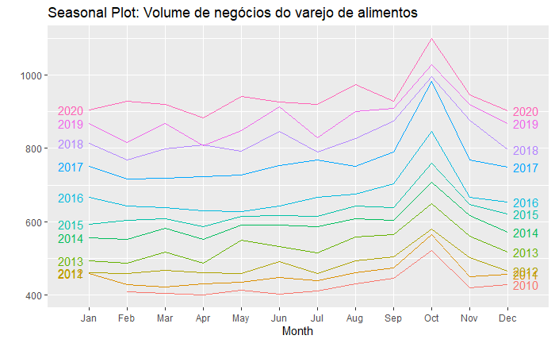

```r
ggseasonplot(turnover_new_south_wales_food_retailing.ts, year.labels=TRUE, year.labels.left=TRUE) +
ylab("") +
ggtitle("Seasonal Plot: Volume de negócios do varejo de alimentos ")
```

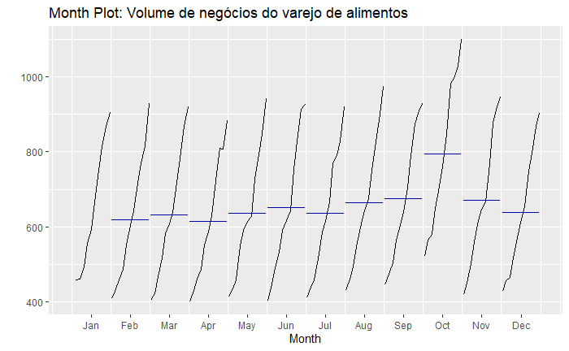

```r
ggmonthplot(turnover_new_south_wales_food_retailing.ts, year.labels=TRUE, year.labels.left=TRUE) +
ylab("") +
ggtitle("Month Plot: Volume de negócios do varejo de alimentos")
```

4. Decomponha a série utilizando o método X11. Ele revela algum outlier ou padrões anômalos não identificados anteriormente?

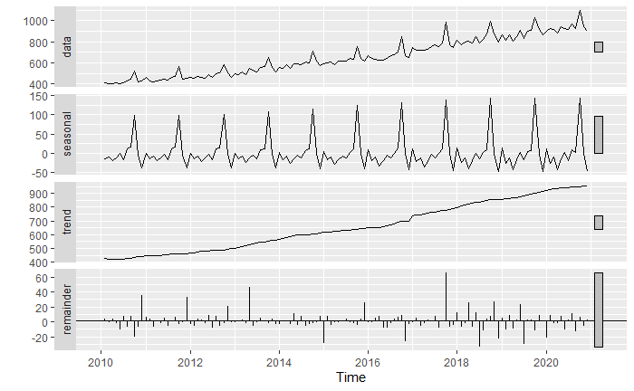

```r
turnover_new_south_wales_food_retailing.sa <- seas(x =  turnover_new_south_wales_food_retailing.ts, transform.function="none", x11="")


autoplot(turnover_new_south_wales_food_retailing.sa,facet=T)
```

```r
outlier(turnover_new_south_wales_food_retailing.sa)
```

```
     Jan Feb Mar Apr May Jun Jul Aug Sep Oct Nov Dec
2010      NA  NA  NA  NA  NA  NA  NA  NA  NA  NA  NA
2011  NA  NA  NA  NA  NA  NA  NA  NA  NA  NA  NA  NA
2012  NA  NA  NA  NA  NA  NA  NA  NA  NA  NA  NA  NA
2013  NA  NA  NA  NA  NA  NA  NA  NA  NA  NA  NA  NA
2014  NA  NA  NA  NA  NA  NA  NA  NA  NA  NA  NA  NA
2015  NA  NA  NA  NA  NA  NA  NA  NA  NA  NA  NA  NA
2016  NA  NA  NA  NA  NA  NA  NA  NA  NA  NA  NA  NA
2017  LS  NA  NA  NA  NA  NA  NA  NA  NA  AO  NA  NA
2018  NA  NA  NA  NA  NA  NA  NA  NA  NA  NA  NA  NA
2019  NA  NA  NA  NA  NA  NA  NA  NA  NA  NA  NA  NA
2020  NA  NA  NA  NA  NA  NA  NA  NA  NA  NA  NA  NA
```

# Parte 2

A ideia desta segunda parte da avaliação é propiciar aos alunos oportunidade de aplicar todo o ferramental aprendido em datasets razoavelmente ricos e propícios à analises descritivas. Aqui não será pedido nenhum tipo de análise específica, mas sim que o aluno explore ao máximo as bases, de modo a transformar dado em informação útil e de fácil absorção! Todo tipo de insight e análise que puder ser retirado das bases é útil, pois ajuda a compreender fenômenos implícitos nos dados. Usem e abusem dos pacotes e funções aprendidas, do Google e do material complementar recomendado no material. Ambos datasets fazem parte do chamado “Tidy Tuesday”, um evento semanal onde a cada terça-feira um novo dataset e disponibilizado e membro da comunidade R fazem análises e/ou aplicam visualizações interessantes e novas.

### 3. Dataset Spotify - package “spotifyr”

Os autores do package compilaram mais de 5.000 músicas de gêneros e subgêneros distintos. O descritivo do dataset, bem como a obtenção dos dados em si, está toda no seguinte repositório: <https://github.com/rfordatascience/tidytuesday/ blob/master/data/2020/2020-01-21/readme.md>

1. Use e abuse de todo o ferramental aprendido (e também do que será aprendido, por ventura, em consultas ao Google). A avaliação será feita tanto em cima da riqueza do código em si (em termos do ferramental usado) quanto do aprofundamento analítico na exploração dos dados e obtenção de informações e relações úteis.

```r
spotify_songs <- readr::read_csv('https://raw.githubusercontent.com/rfordatascience/tidytuesday/master/data/2020/2020-01-21/spotify_songs.csv')
spotify_songs <- spotify_songs %>% mutate(track_popularity = as.numeric(track_popularity) )
```

Gêneros no dataset

```r
genre <- janitor::tabyl(spotify_songs$playlist_genre)

genre
```

```
 spotify_songs$playlist_genre    n   percent
                          edm 6043 0.1840526
                        latin 5155 0.1570067
                          pop 5507 0.1677276
                          r&b 5431 0.1654128
                          rap 5746 0.1750069
                         rock 4951 0.1507934
```

Artistas no dataset

```r
artists <- spotify_songs %>% count(substr(track_artist, 0, 10))


artists
```

| substr(track_artist, 0, 10) | n |
| --- | --- |
| 'Til Tuesd | 2 |
| -M- | 1 |
| !!! | 2 |
| !deladap | 5 |
| "Dear Evan | 1 |
| #TocoParaV | 1 |
| $ANFI | 3 |
| $IFRA | 1 |
| $uicideBoy | 28 |
| (dc) | 1 |

[output cut: 990 more lines]

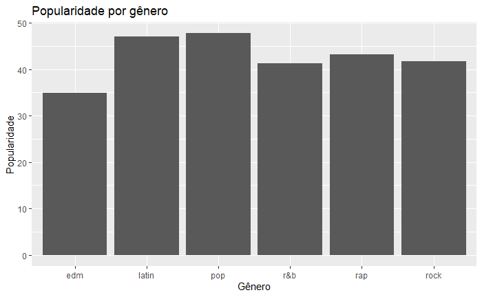

```r
spotify_songs %>% group_by(playlist_genre) %>%
  summarise(pop = sum(track_popularity) / n()) %>%
  ungroup() %>%
  ggplot() + geom_col(aes(y=pop, x = playlist_genre)) +
  labs(title = "Popularidade por gênero",
       y = "Popularidade",
       x = "Gênero")
```

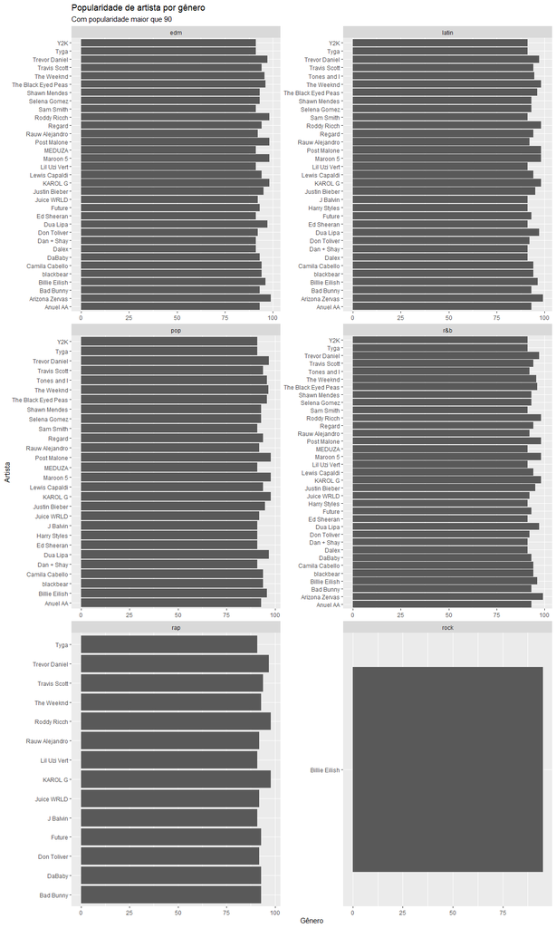

```r
spotify_songs %>% filter (track_popularity > 90)  %>% group_by(track_artist, playlist_genre) %>%
  summarise(pop = sum(track_popularity) / n()) %>%
  arrange(pop) %>%
  ungroup() %>%
  ggplot() + geom_col(aes(y = track_artist, x = pop)) +
  facet_wrap(~playlist_genre, scales="free", ncol = 2) +
  labs(title = "Popularidade de artista por gênero",
       subtitle = "Com popularidade maior que 90",
       y = "Artista",
       x = "Gênero")
```

## 4. Video Games Dataset

O dataset contém dados como a data de lançamento, desenvolvedor, tempo médio jogado, etc. O descritivo do dataset, bem como a obtenção dos dados em si, está toda no seguinte repositório: <https://github.com/rfordatascience/tidytuesday/ tree/master/data/2019/2019-07-30>

1. Use e abuse de todo o ferramental aprendido (e também do que será aprendido, por ventura, em consultas ao Google). A avaliação será feita tanto em cima da riqueza do código em si (em termos do ferramental usado) quanto do aprofundamento analítico na exploração dos dados e obtenção de informações e relações úteis.

```r
# clean dataset from lizawood's github
url <- "https://raw.githubusercontent.com/lizawood/apps-and-games/master/PC_Games/PCgames_2004_2018_raw.csv"

# read in raw data
raw_df <- url %>%
  read_csv() %>%
  janitor::clean_names()
# clean up some of the factors and playtime data
clean_df <- raw_df %>%
  mutate(price = as.numeric(price),
         score_rank = word(score_rank_userscore_metascore, 1),
         average_playtime = word(playtime_median, 1),
         median_playtime = word(playtime_median, 2),
         median_playtime = str_remove(median_playtime, "\\("),
         median_playtime = str_remove(median_playtime, "\\)"),
         average_playtime = 60 * as.numeric(str_sub(average_playtime, 1, 2)) +
           as.numeric(str_sub(average_playtime, 4, 5)),
         median_playtime = 60 * as.numeric(str_sub(median_playtime, 1, 2)) +
           as.numeric(str_sub(median_playtime, 4, 5)),
         metascore = as.double(str_sub(score_rank_userscore_metascore, start = -4, end = -3))) %>%
  select(-score_rank_userscore_metascore, -score_rank, -playtime_median) %>%
  rename(publisher = publisher_s, developer = developer_s)
```

[output not shown]

Preço médio

```r
summary(clean_df$price)
```

```
   Min. 1st Qu.  Median    Mean 3rd Qu.    Max.    NA's
  0.490   2.990   5.990   8.947   9.990 595.990    3095
```

Jogos por desenvolvedor

```r
df_cleaned_year <- clean_df %>%
  mutate(year = substr(release_date,
                            (nchar(release_date)+1)-4,nchar(release_date)))
totalByDev <- df_cleaned_year %>%
   filter( is.na(developer) == FALSE) %>%
  group_by(developer, year) %>%
  summarise(total =  n()) %>%
  arrange(desc(total))

totalByDev
```

| developer | year | total |
| --- | --- | --- |
| Ripknot Systems | 2018 | 42 |
| Laush Dmitriy Sergeevich | 2018 | 41 |
| KOEI TECMO GAMES CO., LTD. | 2017 | 38 |
| Nikita "Ghost_RUS" | 2018 | 38 |
| Nekyau Games | 2018 | 35 |
| SEGA | 2010 | 34 |
| EnsenaSoft | 2016 | 31 |
| Garnudo Games | 2018 | 30 |
| Choice of Games | 2018 | 27 |
| Red Dolphin Games | 2018 | 26 |

[output cut: 990 more lines]

[figure not shown]

```r
totalByDev %>%
  group_by(year) %>%
  summarise(total =  n()) %>%
  arrange(desc(total)) %>%
  ggplot() + geom_col(aes(y=year, x = total)) +
  labs(title = "Jogos lançados por ano",
       y = "Total",
       x = "Ano")
```

```r
NA
```